# PS2 — Event-Driven Congestion · Exploratory Data Analysis

**Flipkart × Bengaluru Traffic Police.** This notebook explores the provided incident dataset only (no external data) to ground the modelling of three targets — `requires_road_closure` (T1), `priority` (T2) and `resolution_time` (T3) — and surfaces the three data findings that shaped every downstream decision:

1. **End-point coordinates leak the closure label** (recorded *because* a closure happened).
2. **Priority is a deterministic function of corridor** — a rule, not a prediction.
3. **Resolution time is partly a recording artifact** + a multi-week civic-process tail.

```python
import sys, os
sys.path.insert(0, r'C:\Users\user\grid_lock_phase_2')
os.environ.setdefault('PYTHONBREAKPOINT','0')
import numpy as np, pandas as pd
from IPython.display import Image
from src import eda, config as C
raw, df = eda.load()
paths = eda.generate_all()   # (re)generate all figures into reports/figures/eda
print('rows:', len(df), '| columns:', raw.shape[1])
print('period:', df['start_datetime'].min().date(), '->', df['start_datetime'].max().date())
```

```
rows: 8171 | columns: 46
period: 2023-09-29 -> 2024-04-08
```

## 1. Overview & data quality

|  | pct_missing |
| --- | --- |
| comment | 100.0 |
| map_file | 100.0 |
| meta_data | 100.0 |
| direction | 99.5 |
| resolved_at_address | 99.1 |
| resolved_at_latitude | 99.1 |
| resolved_by_id | 99.1 |
| resolved_datetime | 99.1 |
| resolved_at_longitude | 99.1 |
| assigned_to_police_id | 98.4 |
| citizen_accident_id | 98.4 |
| route_path | 98.3 |

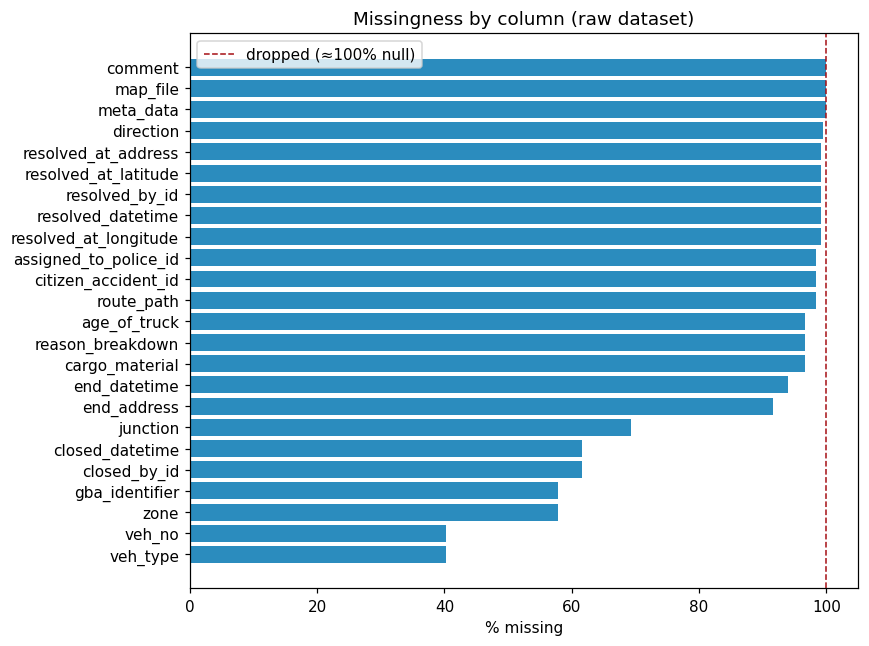

```python
nr = (raw.isna().mean()*100).round(1).sort_values(ascending=False)
display(nr.head(12).to_frame('pct_missing'))
Image(str(C.FIGURES_DIR/'eda'/'01_null_rates.png'))
```

## 2. Prediction targets

T1 is **imbalanced** (~8% closures). T2 is ~62% High. T3 (resolution minutes) is **heavy-tailed** — and, critically, for the dominant breakdown class it clusters at ~135 min (records auto-modified ~2h after start, not a real clearance signal).

```
T1 closure %: 8.3
T2 High %   : 61.6
```

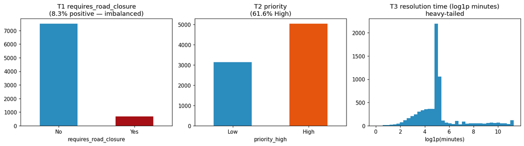

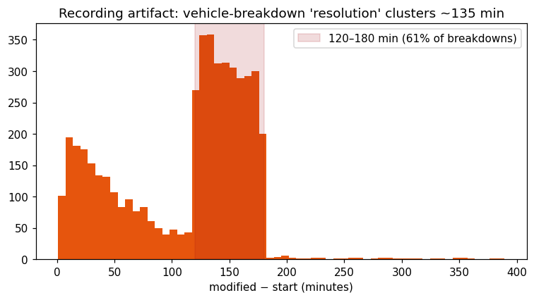

```python
print('T1 closure %:', round(df[C.T1].mean()*100,1))
print('T2 High %   :', round(df[C.T2].mean()*100,1))
display(Image(str(C.FIGURES_DIR/'eda'/'02_target_distributions.png')))
Image(str(C.FIGURES_DIR/'eda'/'03_breakdown_artifact.png'))
```

## 3. What drives a road closure?

Closure is overwhelmingly **event-driven**: VIP movement, public events, protests, tree-fall and construction close roads far more than breakdowns/accidents. **Planned events** close roads ~5× as often as unplanned — exactly the PS focus.

| event_cause_norm | closure_rate |
| --- | --- |
| vip_movement | 0.800 |
| public_event | 0.464 |
| protest | 0.400 |
| tree_fall | 0.394 |
| construction | 0.265 |
| procession | 0.264 |
| debris | 0.154 |
| road_conditions | 0.124 |
| others | 0.086 |
| water_logging | 0.085 |

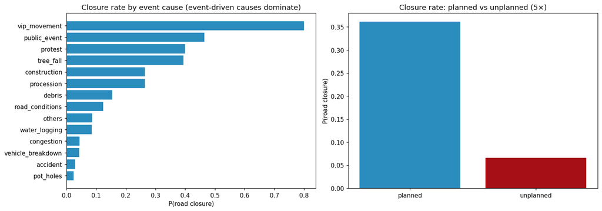

```python
cr = df.groupby('event_cause_norm')['rc'].mean().sort_values(ascending=False)
display(cr.head(10).to_frame('closure_rate').round(3))
Image(str(C.FIGURES_DIR/'eda'/'04_closure_drivers.png'))
```

## 4. Temporal patterns

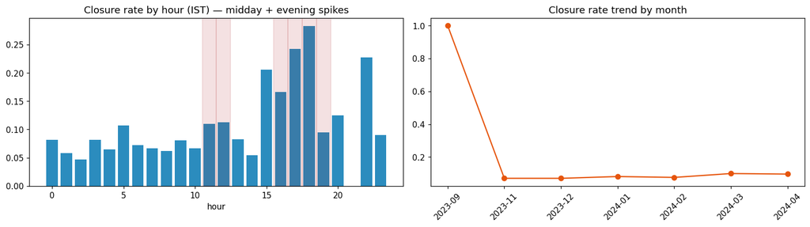

```python
Image(str(C.FIGURES_DIR/'eda'/'05_temporal.png'))
```

## 5. Spatial structure

Clean Bengaluru bounding box, no null coordinates → internal spatial features (~1 km hotspot grid, distance-to-centroid) are viable without any external data. A handful of locations recur heavily (e.g. ORR-Marathahalli).

| address | incidents |
| --- | --- |
| Outer Ring Road, Karthik Nagar, Marathahalli, Bengaluru, Karnataka. Pin-560037 (India) | 88 |
| 2nd Cross Road, MTB Area, Jayanagar, Bengaluru, Karnataka. Pin-560041 (India) | 44 |
| Sankey Road, RV Layout, Seshadripuram, Bengaluru, Karnataka. Pin-560020 (India) | 36 |
| MBT Road, Block 5 Stage 1, HBR Layout, Bengaluru, Karnataka. Pin-560043 (India) | 35 |
| Sankey Road, MD Nanjundaswamy Circle, Rajamahal Guttahalli, Bengaluru, Karnataka. Pin-560003 (India) | 34 |

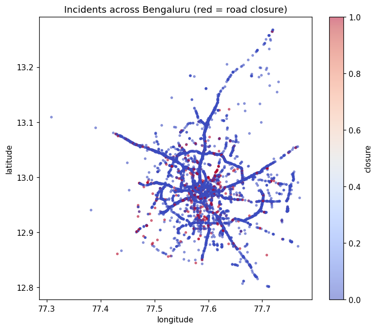

```python
display(df['address'].value_counts().head(5).to_frame('incidents'))
Image(str(C.FIGURES_DIR/'eda'/'06_spatial.png'))
```

## 6. ⚠️ Headline audit — leakage, determinism & the artifact

These three findings are *the* differentiator: they prevent a hollow 0.98-F1 model and dictate honest evaluation.

```
End-point present vs closure (LEAKAGE):
```

| closure has_end_point | 0 | 1 |
| --- | --- | --- |
| 0 | 7482 | 0 |
| 1 | 13 | 676 |

```
Corridors that are NOT ~pure High/Low (priority determinism): 0 of 22
```

[figure not shown]

```python
has_end = (df['endlatitude'].fillna(0)!=0).astype(int)
print('End-point present vs closure (LEAKAGE):')
display(pd.crosstab(has_end, df[C.T1], rownames=['has_end_point'], colnames=['closure']))
mixed = df.groupby('corridor')[C.T2].mean()
print('Corridors that are NOT ~pure High/Low (priority determinism):',
      int(((mixed>0.02)&(mixed<0.98)).sum()), 'of', mixed.size)
Image(str(C.FIGURES_DIR/'eda'/'07_leakage_determinism_audit.png'))
```

## 7. Free-text officer notes

~83% of incidents carry a short note (English/Kanglish ~87%, Kannada ~13%). These are mined into structured features (severity, lane-blocking, tow-needed, subtype) via a local multilingual LLM (qwen2.5:3b) with a fast rule-based fallback.

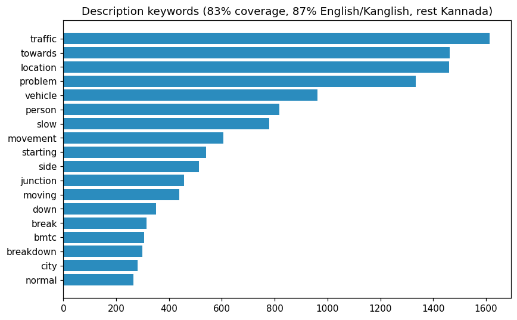

```python
Image(str(C.FIGURES_DIR/'eda'/'08_text_keywords.png'))
```

## 8. Takeaways → modelling

- **T1**: learnable; ban end-point features; key signals = event_cause, is_planned, corridor recurrence, LLM severity. Use PR-AUC + calibrated probabilities.
- **T2**: present honestly as the corridor rule (+ a corridor-blind sanity model).
- **T3**: artifact-limited; use AFT survival (uses censored 'active' incidents) for ranking + a 6h-capped regressor for point estimates; report robust metrics and the data-quality recommendation.
- **Splitting**: strictly chronological; recurrence features are past-only.